# Chapter 15 - Missing data and other opportunities

```r
library(tidyverse)
library(dagitty)
```

Bayesian modeling comes down to “Assume, then deduce.” In this chapter, we’ll review two such examples: (1) Measurement error and (2) Bayesian Imputation

# Measurement error

```r
suppressPackageStartupMessages(library(rethinking))
data(WaffleDivorce)
d <- WaffleDivorce
rm(WaffleDivorce)

detach(package:rethinking, unload = T)
suppressPackageStartupMessages(library(brms))
```

When we used the divorce rate data set earlier, we ignored the fact that measurement error was also recorded for both the divorce rate variable and the median age at marriage variable. Large states provided better samples so their measurement error is smaller.

Since large states give us better information, it makes sense for them to influence our regression more.

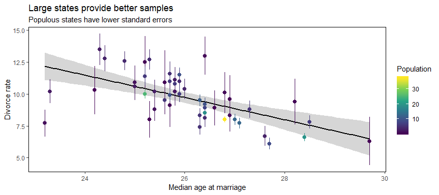

```r
ggplot(d, aes(x = MedianAgeMarriage,
              y = Divorce,
              ymin = Divorce - Divorce.SE,
              ymax = Divorce + Divorce.SE,
              colour = Population)) +
  geom_smooth(method = "lm", colour = "black") +
  geom_pointrange() +
  scale_color_viridis_c() +
  theme(panel.grid = element_blank(),
        panel.background = element_rect(fill = "white", colour = "black")) +
  ggtitle("Large states provide better samples", "Populous states have lower standard errors") +
  xlab("Median age at marriage") + ylab("Divorce rate")
```

## Error on the outcome variable

Measurement error on the outcome variable can just be thought of as a function of the true value and the error - which is determined by the population size of each state.

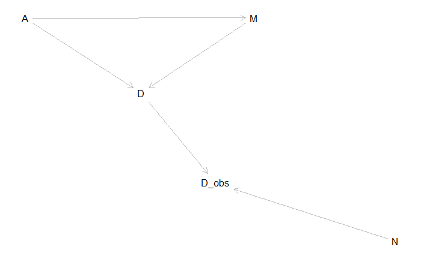

```r
g <- dagitty( "dag{
A -> M
M -> D
A -> D
D -> D_obs
N -> D_obs}")
plot(graphLayout(g))
```

Lets formalize this a bit more
$$\begin{align}
Divorce_{estimated, i} & \sim Normal(\mu_i, \sigma)
\\
\mu & = \alpha + \beta_1A_i + \beta_2R_i
\\
Divorce_{observed, i} & \sim Normal(Divorce_{estimated,i}, Divorce_{standard\_error, i})
\\
\text{...priors...}
\end{align}$$

First lets code this up with rethinking

```r
suppressPackageStartupMessages(library(rethinking))
dlist <- list(
  D_obs = standardize(d$Divorce),
  D_sd = d$Divorce.SE / sd(d$Divorce),
  M = standardize(d$Marriage),
  A = standardize(d$MedianAgeMarriage),
  N = nrow(d)
)

m15.1 <- ulam(
  alist(
    D_obs ~ dnorm(D_true, D_sd),
    vector[N]:D_true ~ dnorm(mu, sigma),
    mu <- a + bA*A + bM*M,
    a ~ dnorm(0, 0.2),
    bA ~ dnorm(0, 0.5),
    bM ~ dnorm(0, 0.5),
    sigma ~ dexp(1)
  ), data = dlist, chains = 4, cores = 4)

summary(m15.1)
```

```
Inference for Stan model: 3315432af9df5a89f17713f8aa7b596d.
4 chains, each with iter=1000; warmup=500; thin=1;
post-warmup draws per chain=500, total post-warmup draws=2000.

             mean se_mean   sd   2.5%    25%    50%    75%  97.5% n_eff Rhat
D_true[1]    1.17    0.01 0.36   0.49   0.92   1.16   1.41   1.89  1457 1.00
D_true[2]    0.70    0.01 0.54  -0.34   0.34   0.69   1.05   1.80  1730 1.00
D_true[3]    0.43    0.01 0.35  -0.23   0.19   0.42   0.67   1.14  2541 1.00
D_true[4]    1.42    0.01 0.44   0.55   1.11   1.41   1.70   2.31  2101 1.00
D_true[5]   -0.91    0.00 0.13  -1.18  -0.99  -0.90  -0.82  -0.65  2109 1.00
D_true[6]    0.66    0.01 0.41  -0.12   0.39   0.66   0.94   1.44  2025 1.00
D_true[7]   -1.36    0.01 0.35  -2.06  -1.60  -1.36  -1.13  -0.69  2397 1.00
D_true[8]   -0.34    0.01 0.48  -1.29  -0.65  -0.34  -0.02   0.65  2166 1.00
D_true[9]   -1.88    0.01 0.62  -3.04  -2.29  -1.88  -1.45  -0.64  2149 1.00
D_true[10]  -0.62    0.00 0.17  -0.97  -0.73  -0.61  -0.51  -0.28  2667 1.00
D_true[11]   0.77    0.01 0.28   0.23   0.58   0.76   0.95   1.35  2817 1.00
D_true[12]  -0.56    0.01 0.47  -1.47  -0.89  -0.56  -0.26   0.35  2098 1.00
D_true[13]   0.15    0.02 0.50  -0.87  -0.19   0.17   0.51   1.07   994 1.01
D_true[14]  -0.87    0.00 0.23  -1.31  -1.02  -0.88  -0.73  -0.42  2694 1.00
D_true[15]   0.55    0.01 0.31  -0.03   0.34   0.55   0.76   1.16  2262 1.00
D_true[16]   0.28    0.01 0.37  -0.43   0.03   0.28   0.54   1.04  2491 1.00
D_true[17]   0.48    0.01 0.42  -0.34   0.21   0.49   0.76   1.31  3058 1.00
D_true[18]   1.26    0.01 0.34   0.63   1.02   1.26   1.50   1.93  2140 1.00
D_true[19]   0.44    0.01 0.38  -0.27   0.18   0.42   0.69   1.19  1976 1.00
D_true[20]   0.42    0.02 0.54  -0.62   0.05   0.41   0.77   1.50  1173 1.00
D_true[21]  -0.55    0.01 0.31  -1.18  -0.77  -0.54  -0.35   0.06  2219 1.00
D_true[22]  -1.10    0.01 0.26  -1.63  -1.28  -1.11  -0.92  -0.58  2337 1.00
D_true[23]  -0.28    0.01 0.27  -0.80  -0.45  -0.28  -0.10   0.24  2213 1.00
D_true[24]  -1.00    0.01 0.28  -1.54  -1.19  -1.01  -0.81  -0.47  2224 1.00
D_true[25]   0.44    0.01 0.41  -0.34   0.16   0.43   0.71   1.23  2117 1.00
D_true[26]  -0.04    0.01 0.33  -0.70  -0.25  -0.03   0.18   0.60  2743 1.00
D_true[27]  -0.03    0.01 0.51  -1.03  -0.36  -0.01   0.31   0.98  2844 1.00
D_true[28]  -0.15    0.01 0.40  -0.95  -0.42  -0.15   0.13   0.63  1790 1.00
D_true[29]  -0.27    0.01 0.49  -1.19  -0.60  -0.29   0.05   0.81  1637 1.00
D_true[30]  -1.80    0.00 0.23  -2.26  -1.96  -1.80  -1.64  -1.36  2496 1.00
D_true[31]   0.17    0.01 0.42  -0.65  -0.12   0.15   0.45   0.98  2472 1.00
D_true[32]  -1.66    0.00 0.17  -1.99  -1.77  -1.66  -1.55  -1.34  2683 1.00
D_true[33]   0.11    0.00 0.24  -0.38  -0.05   0.11   0.28   0.58  2825 1.00
D_true[34]  -0.07    0.01 0.53  -1.21  -0.38  -0.05   0.30   0.89  2048 1.00
D_true[35]  -0.12    0.00 0.22  -0.55  -0.27  -0.12   0.04   0.30  3059 1.00
```

[output cut: 10 more lines]

```
D_true[46]  -0.39    0.01 0.26  -0.90  -0.56  -0.39  -0.23   0.13  2542 1.00
D_true[47]   0.13    0.01 0.30  -0.47  -0.07   0.13   0.32   0.72  2740 1.00
D_true[48]   0.55    0.01 0.47  -0.35   0.24   0.55   0.85   1.52  2251 1.00
D_true[49]  -0.63    0.00 0.27  -1.17  -0.81  -0.63  -0.44  -0.10  2943 1.00
D_true[50]   0.85    0.01 0.57  -0.28   0.48   0.84   1.23   1.96  1560 1.00
a           -0.05    0.00 0.10  -0.24  -0.12  -0.06   0.01   0.14  1441 1.00
bA          -0.61    0.01 0.17  -0.92  -0.72  -0.62  -0.50  -0.27  1109 1.00
bM           0.05    0.01 0.17  -0.27  -0.06   0.05   0.17   0.39   969 1.00
sigma        0.59    0.00 0.11   0.40   0.51   0.58   0.66   0.83   510 1.01
lp__       -25.62    0.35 6.94 -40.48 -30.04 -25.26 -20.73 -13.28   401 1.01

Samples were drawn using NUTS(diag_e) at Sun Jun 02 17:02:37 2019.
For each parameter, n_eff is a crude measure of effective sample size,
and Rhat is the potential scale reduction factor on split chains (at
convergence, Rhat=1).
```

[output not shown]

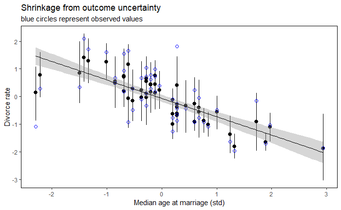

```r
post <- extract.samples(m15.1)
as_tibble(post$D_true, .name_repair = "unique") %>%
  gather %>%
  group_by(key) %>%
  mean_hdi() %>%
  mutate(key = as.numeric(str_sub(key, 4))) %>%
  arrange(key) %>%
  mutate(d_obs = dlist$D_obs,
         age = dlist$A) %>%
  ggplot(aes(x = age, y = value, ymin = .lower, ymax = .upper)) +
    geom_pointrange() +
    geom_point(aes(y = d_obs), colour = "blue", size = 2, shape = 1) +
    geom_smooth(aes(x = age, y = value), method = lm, colour = "black", size = .7) +
    theme(panel.background = element_rect(fill = "transparent", colour = "black"),
          panel.grid = element_blank()) +
    xlab("Median age at marriage (std)") +
    ylab("Divorce rate") +
    ggtitle("Shrinkage from outcome uncertainty", "blue circles represent observed values")
```

The graph above shows us that less certain estimate are improved by pooling information from more certain estimates.

In BRMS, we can use the special function `mi` to implement the above specification.

```r
dlist <- list(
  div_obs = d$Divorce,
  div_sd = d$Divorce.SE,
  R = d$Marriage,
  A = d$MedianAgeMarriage)

inits <- list(Yl = dlist$div_obs)
inits_list <- list(inits, inits)

b14.1_mi <-
  brm(data = dlist, family = gaussian,
      div_obs | mi(div_sd) ~ 0 + intercept + R + A,
      prior = c(prior(normal(0, 10), class = b),
                prior(cauchy(0, 2.5), class = sigma)),
      iter = 5000, warmup = 1000, cores = 2, chains = 2,
      seed = 14,
      control = list(adapt_delta = 0.99,
                     max_treedepth = 12),
      save_mevars = TRUE,  # note this line for the `mi()` model
      inits = inits_list)
summary(b14.1_mi)
```

```
 Family: gaussian
  Links: mu = identity; sigma = identity
Formula: div_obs | mi(div_sd) ~ 0 + intercept + R + A
   Data: dlist (Number of observations: 50)
Samples: 2 chains, each with iter = 5000; warmup = 1000; thin = 1;
         total post-warmup samples = 8000

Population-Level Effects:
          Estimate Est.Error l-95% CI u-95% CI Eff.Sample Rhat
intercept    21.18      6.67     7.57    33.78       3540 1.00
R             0.13      0.08    -0.02     0.28       3992 1.00
A            -0.54      0.22    -0.95    -0.11       3689 1.00

Family Specific Parameters:
      Estimate Est.Error l-95% CI u-95% CI Eff.Sample Rhat
sigma     1.14      0.21     0.77     1.58       2299 1.00

Samples were drawn using sampling(NUTS). For each parameter, Eff.Sample
is a crude measure of effective sample size, and Rhat is the potential
scale reduction factor on split chains (at convergence, Rhat = 1).
```

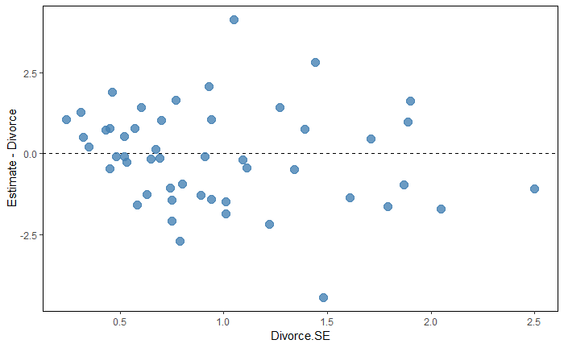

```r
data_error <-
  fitted(b14.1_mi) %>%
  as_tibble() %>%
  bind_cols(d)

data_error %>%
  ggplot(aes(x = Divorce.SE, y = Estimate - Divorce)) +
  geom_hline(yintercept = 0, linetype = 2) +
    geom_point(colour = "steelblue", size = 3.5, alpha = .8) +
    theme(panel.background = element_rect(fill = "transparent", colour = "black"),
          panel.grid = element_blank())
```